# Lab 2: Examining College Data

Exercise 4:

```r
private.outofstate <- subset(out.of.state, control == "Private")
mean(private.outofstate)
```

```
## [1] 58540.12
```

```r
public.outofstate <- subset(out.of.state, control == "Public")
mean(public.outofstate)
```

```
## [1] 37638.43
```

```r
sd(private.outofstate)
```

```
## [1] 4859.443
```

```r
sd(public.outofstate)
```

```
## [1] 7798.708
```

Public, out-of-state institutions have a greater variation in cost.

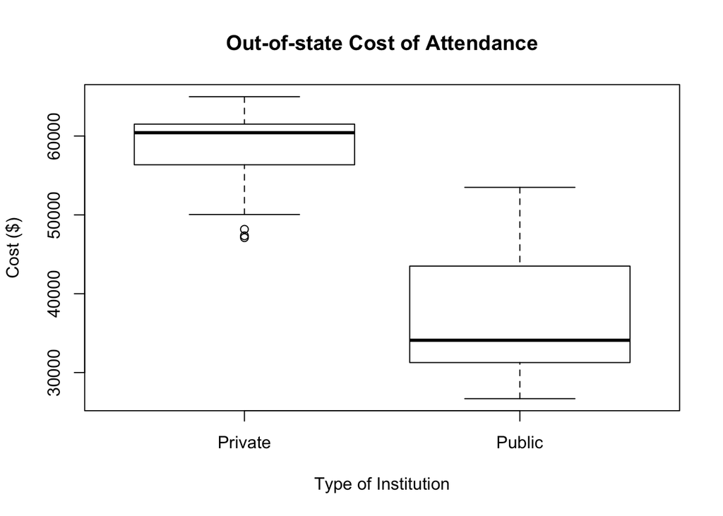

```r
boxplot(private.outofstate, public.outofstate, main = "Out-of-state Cost of Attendance", xlab = "Type of Institution", ylab = "Cost ($)", names = c ("Private", "Public"))
```

```r
labels = c("Private", "Public")
```

Out-of-state cost and institutional control appear to be associated as well. Private institutions are still more expensive than public ones, but compared to the previous boxplot [comparing in-state cost of attendance], the gap between the two has become closer, reaching some overlap. The minimum cost to attend a private instution is no longer greater than the maximum cost to attend a public institution, meaning that attending a private school can be the most inexpensive option in some cases.

Exercise 5:

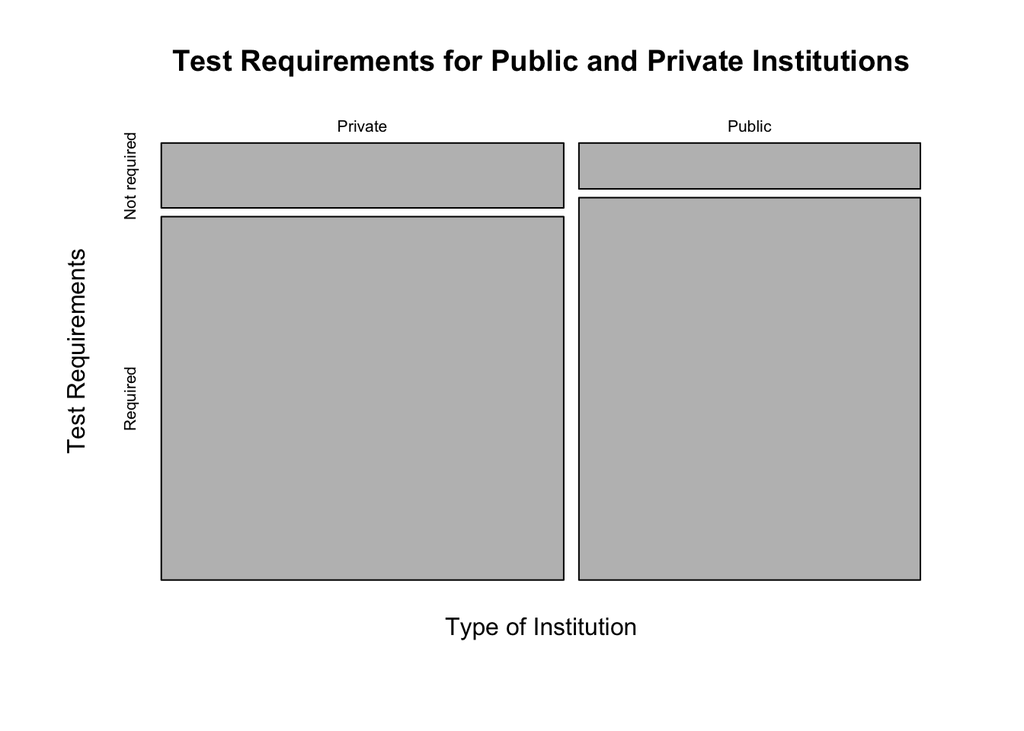

```r
mosaicplot(control~tests.required, main="Test Requirements for Public and Private Institutions", xlab = "Type of Institution", ylab = "Test Requirements")
```

Both public and private institutions generally require standardized tests, but overall, private institutions do not require them compared to public institutions.

Exercise 6:

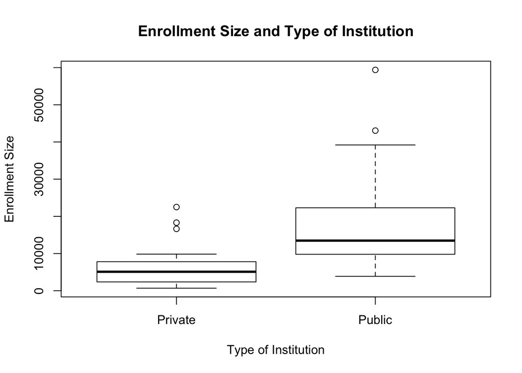

```r
boxplot(enrollment.undergrad~control, main = "Enrollment Size and Type of Institution", xlab = "Type of Institution", ylab = "Enrollment Size")
```

Enrollment size and type of institution seem to be associated. The boxplot shows that more students tend to be enrolled at public institutions than private institutions.

Exercise 7:

```r
summary(white)
```

```
##    Min. 1st Qu.  Median    Mean 3rd Qu.    Max.
##    0.00   44.00   56.00   52.77   66.00   82.00
```

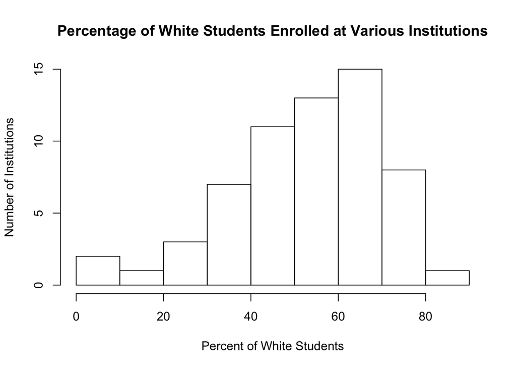

```r
hist(white, main = "Percentage of White Students Enrolled at Various Institutions" ,ylab = "Number of Institutions" ,xlab = "Percent of White Students")
```

```r
whiteurban <- subset(white, location == "Urban")
summary(whiteurban)
```

```
##    Min. 1st Qu.  Median    Mean 3rd Qu.    Max.
##    0.00   40.75   51.00   50.08   62.50   82.00
```

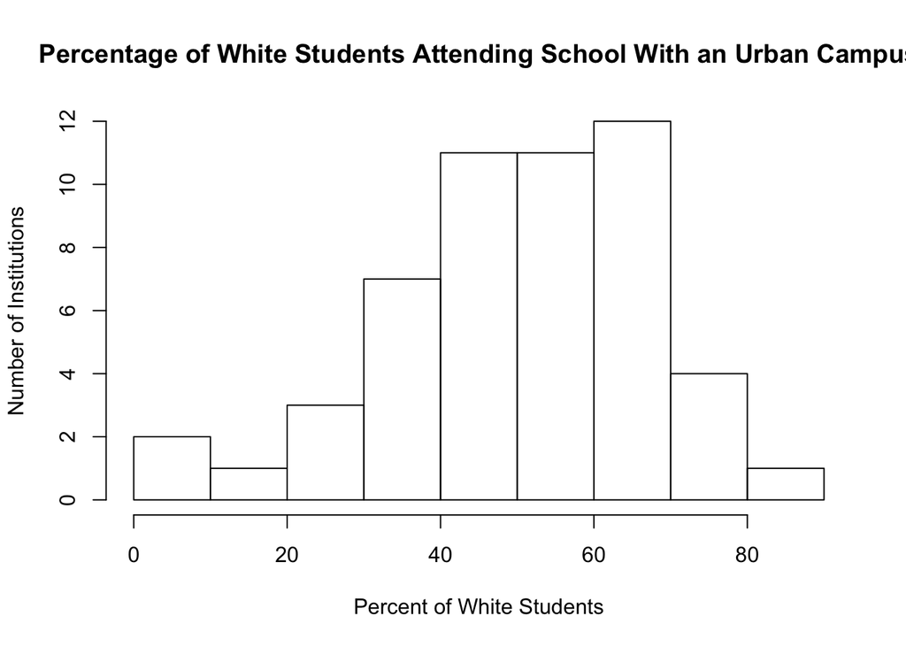

```r
hist(whiteurban, main = "Percentage of White Students Attending School With an Urban Campus", xlab = "Percent of White Students", ylab = "Number of Institutions")
```

This histogram is similar to the previous one because it is also unimodal and left-skewed for the same reasons, but there are slight differences in the mean, median Q1, and Q3.

Exercise 8:

I predict that a school’s instutituion type and campus type will not be associated because campus type does not necessarily affect institution type; both public and private instuitions can have either an urban or rural campus.

```r
table(control, location)
```

```
##          location
## control   Rural Urban
##   Private     7    26
##   Public      2    26
```

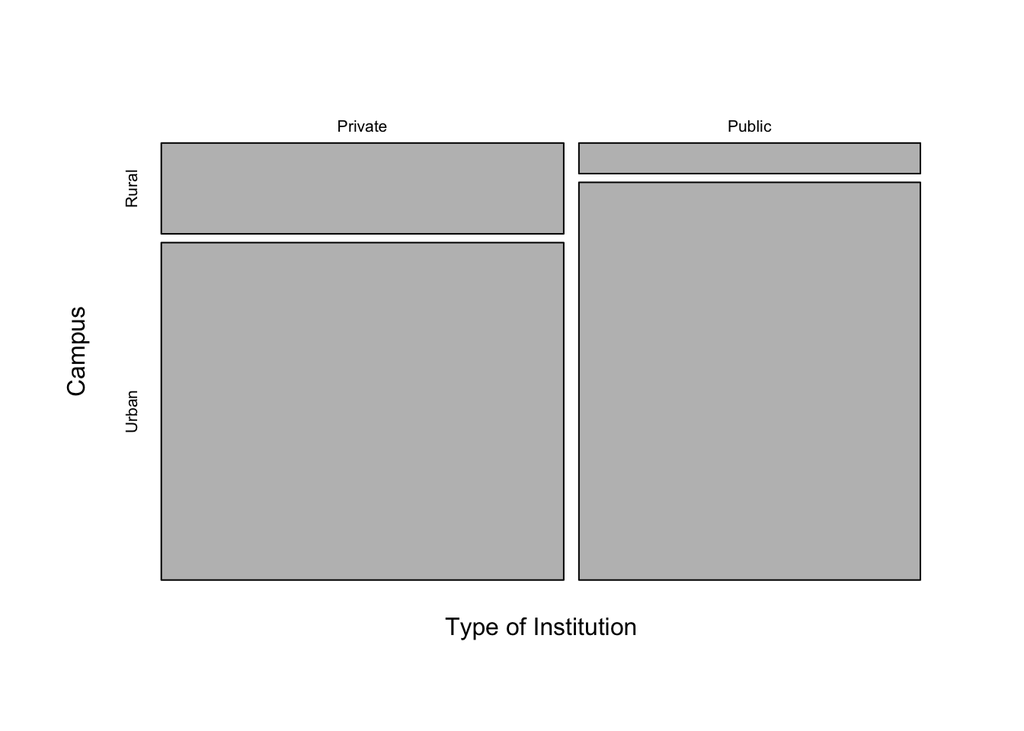

```r
control.location <- table(control, location)
mosaicplot(control.location, main = "", xlab = "Type of Institution", ylab = "Campus")
```

The data suggests that there is an assocation between the type of instuition and campus type. Public schools are more likely to have an urban campus, and there is a higher proportion of private institutions in a rural campus, than public ones.

Exercise 9:

I predict that the percent of women enrolled and type of instuition are associated, since single-sex schools tend to be private institutions. Essentially, my hypothesis is that there is a higher percentage of women enrolled at private schools due to the existence of single-sex schools.

```r
mean(women)
```

```
## [1] 53.95082
```

```r
range(women)
```

```
## [1]   0 100
```

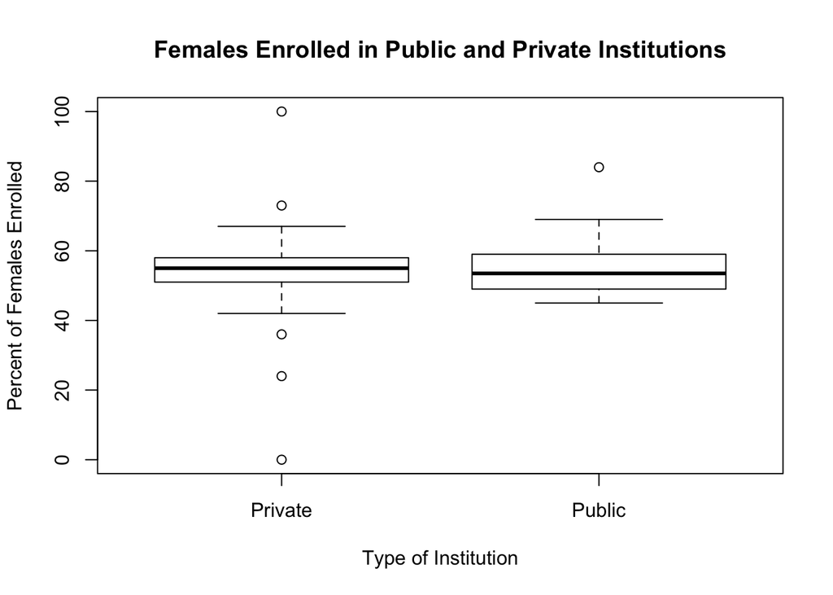

```r
boxplot(women~control, main = "Females Enrolled in Public and Private Institutions", xlab = "Type of Institution", ylab = "Percent of Females Enrolled")
```

The boxplots appear to be very similar, aside from the various outliers enrolled in private institutions. One thing worth mentioning is that the outlier private institutions that have 0% and 100% of women enrolled, are most likely male-only, and female-only, respectively, therefore they may have skewed the data to be higher, or lower than it should be.

The percent of women enrolled and type of institution do not seem to be associated with each other because regardless of institution type, most colleges have an enrollment of 40-60% women.